# STAT 413/613 HW 1

2020-06-19

# Instructions

- Write your solutions in this starter file.
  - Modify the “author” field in the YAML header.
- Commit R Markdown and HTML files (no PDF files). **Push both .Rmd and HTML files to GitHub**.
  - Make sure you have knitted to HTML for your final submission.
  - **Committing each time you answer a part of question, e.g. 1.1, and pushing to Git Hub after each major question, e.g., 1 World Bank Data, is completed is a graded element for this homework.**
- Only include necessary code to answer the questions.
- Most of the functions you use should be from the tidyverse. Too much base R will result in point deductions.
- Feel free to use Pull requests and or email (attach your .Rmd) to ask me any questions.

# Learning Outcomes:

- Operate with Git and GitHub.
- Apply concepts and methods from STAT 412/612.

# 1 World Bank Data

The World Bank provides loans to countries with the goal of reducing poverty. The data frames in the data folder were taken from the public data repositories of the World Bank.

- country.csv: Contains information on the countries in the data set.
  - The variables are:
    - `Country_Code`: A three-letter code for the country. Note not all rows are countries; some are regions.
    - `Region`: The region of the country.
    - `IncomeGroup`: Either `"High income"`, `"Upper middle income"`, `"Lower middle income"`, or `"Low income"`.
    - `TableName`: The full name of the country.
- fertility.csv: Contains the fertility rate information for each country for each year.
  - For the variables `1960` to `2017`, the values in the cells represent the fertility rate in total births per woman for that year.
  - Total fertility rate represents the number of children that would be born to a woman if she were to live to the end of her childbearing years and bear children in accordance with age-specific fertility rates of the specified year.
- life_exp.csv: Contains the life expectancy information for each country for each year.
  - For the variables `1960` to `2017`, the values in the cells represent life expectancy at birth in years for the given year.
  - Life expectancy at birth indicates the number of years a newborn infant would live if prevailing patterns of mortality at the time of its birth were to stay the same throughout its life.
- population.csv: Contains the population information for each country.
  - For the variables `1960` to `2017`, the values in the cells represent the total population in number of people for the given year.
  - Total population is based on the de facto definition of population, which counts all residents regardless of legal status or citizenship. The values shown are midyear estimates.
1. Use relative paths to load these data frames into R.
2. These data are messy. The observational units in `fert`, `life`, and `pop` are locations in space-time (e.g. Aruba in 2017). Recall that tidy data should have one observational unit per row.
- Make these data tidy now.
- Make sure the new year variable is a numeric.
3. Combine these data frames so the fertility rate, population, life expectancy, and the region for each country in each year are in a single data frame.
4. Make a scatterplot of fertility rate vs life expectancy, color-coding by region and annotating size by the population.
- Include only the years 1960, 1970, 1980, 1990, 2000, and 2010. Facet by these years.
- Interpret the plot in one sentence.
- Your final plot should look like this:

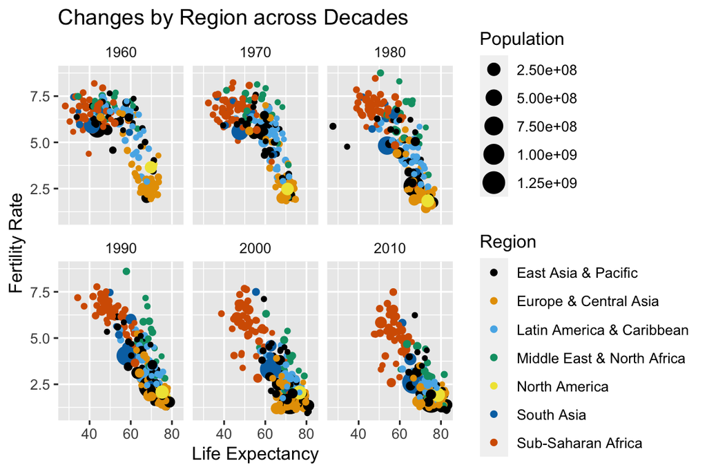

5. Calculate the total population for each region for each year. Exclude 2018.
- Make a line plot of year versus log of total population, color-coding by region.
- Interpret the plot in one sentence.
- Your final plot should look like this:

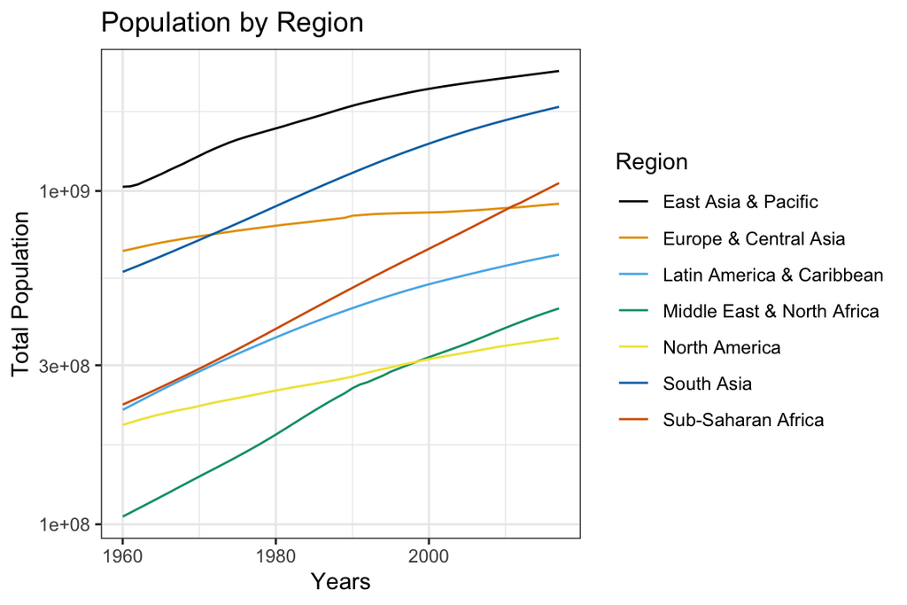

6. Make a bar plot of population vs region for the year 2017.
- Order the bars on the $y$-axis in **decreasing** order of population.
- Your final plot should look like this:

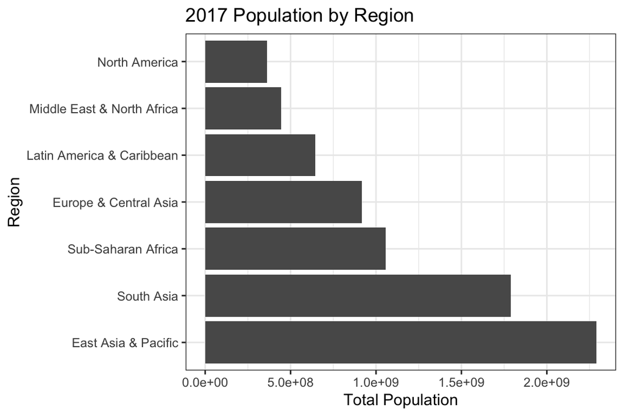

# 2 Scrabble Words

For this exercise, we are using the [Collins Scrabble Words](https://en.wikipedia.org/wiki/Collins_Scrabble_Words), which is most commonly used outside of the United States. The dictionary most often used in the United States is the [Tournament Word List](https://en.wikipedia.org/wiki/Official_Tournament_and_Club_Word_List).

**WARNING**: Do not try `str_view()` or `str_view_all()` on these data. It will stall your computer.

1. Load the 2015 list of Collins Scrabble Words into R from https://data-science-master.github.io/lectures/data/words.txt (note: “NA” is an official Scrabble word).
2. What are the four shortest word that have the most “Z”’s in them?
3. How many words have an identical first and second half of the word?
- For words with an odd number of characters, exclude the middle character from consideration.
- For example, “JIGAJIG” counts because “JIG” is both the first and second half. “MURMUR” also counts because “MUR” is both the first and second half.
4. What is the longest word that has an identical first and second half of the word?